# Wine Data Exploration by Terry Verner

# Bivariate Analysis

### Talk about some of the relationships you observed in this part of the investigation. How did the feature(s) of interest vary with other features in the dataset?

I think there may be relationships between multiple variables rather than simply two variables. Most of the visualizations I developed did not demonstrate a strong or even moderate correlation. Only a handful of plots alone showed a relationship between the two variables.

### Did you observe any interesting relationships between the other features (not the main feature(s) of interest)?

I think the most interesting relationship I uncovered was the moderate, negative correlation between alcohol and residual sugars. Other types of strong alcohols add sugar and mask the strength of the alcohol. This, however, suggests many of the strong wines have lower levels of residual sugar. There may be some process of wine creation that could explain this correlation.

### What was the strongest relationship you found?

The strongest relationship was one I expected: residual sugar vs. density. The density of wine was strongly correlated with residual sugars and that is expected because any residual sugar would add density to a liquid solution.

# Multivariate Plots Section

Let’s create two new categorical variable for better plotting across multiple variables. These will be defined by the following:

```r
white$alcohol_quartiles = cut(white$alcohol,
                              breaks = 4)
```

```r
white$quality_categories <- cut(white$quality,
                                breaks = 3)
```

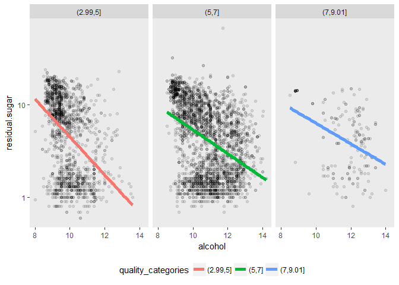

There appears to be almost of sweet spot (no pun intended) for acceptable ranges of residual sugar and they are negatively correlated with alcohol content. Across all three categories of wine quality this holds true.

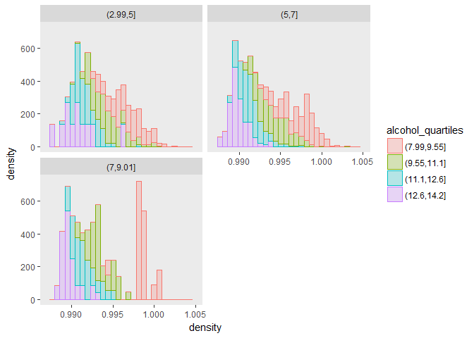

In the previous section, we witnessed a strong correlation (0.839) between density and residual.sugar. Given their correlation and the negative correlation of residual.sugar with alcohol, density could be used in conjunction both of those features to better cluster wines of similar quality.

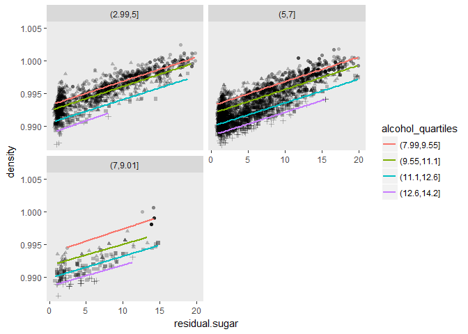

There are multiple encodings in this faceted plot, but it is very informative in terms of clustering qualities of wine. Characterized as density described by residual.sugar, faceted by quality categories, colored and shaped by alcohol quartiles. I notice the higher occurrance of low alcohol levels in the lower rated wines. At the same time, I notice high alcohol levels in the highest rated wines. This suggests higher alcohol content is correlated with higher quality ratings of wine.

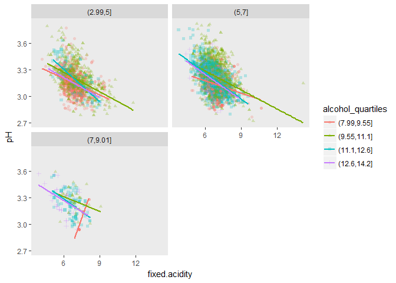

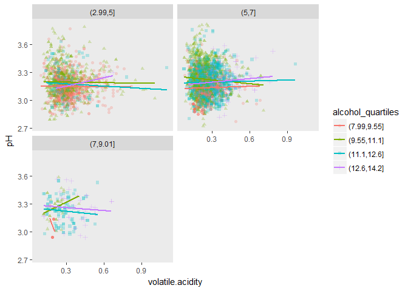

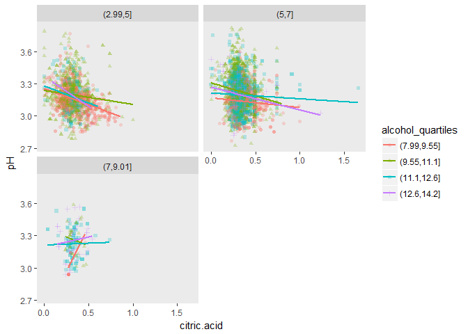

# Multivariate Analysis

### Talk about some of the relationships you observed in this part of the investigation. Were there features that strengthened each other in terms of looking at your feature(s) of interest?

I was surprised by the number of features having little to no correlation on my feature of interest, quality. Having said that, there were a handful of features most descriptive in terms of identifying trends in the dataset.

### Were there any interesting or surprising interactions between features?

I was surprised to see less correlation of the acid items and pH than the data demonstrated. One would expect acids to directly affect the measurement of acidity.

I was also surprised to see weak interactions between many of the features of this dataset. The correlation matrix demonstrated there were very few correlations between a number of the features. I was able to adapt a number of the features and build effective plots; however, the relationships were less apparent than I anticipated.

# Final Plots and Summary

### Plot One

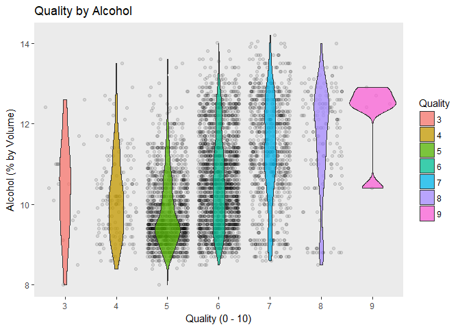

### Description One

The violinplot atop the scatterplot identifies a trend of higher alcohol content correlating with high quality ratings. This correlation serves as a starting point for other plots during the exploratory phase and helps consider other methods of slicing and viewing data in order to glean deeper trends and insights.

### Plot Two

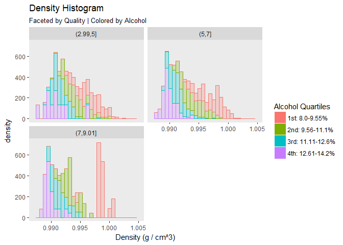

### Description Two

Density provided some insight into alcohol levels by way of the sugars present during the fermentation process were converted to alcohol. The concentration of alcohol and reduction of sugars resulted in lower density levels. This allows for cleaner groupings of qualities and alcohol quartiles.

### Plot Three

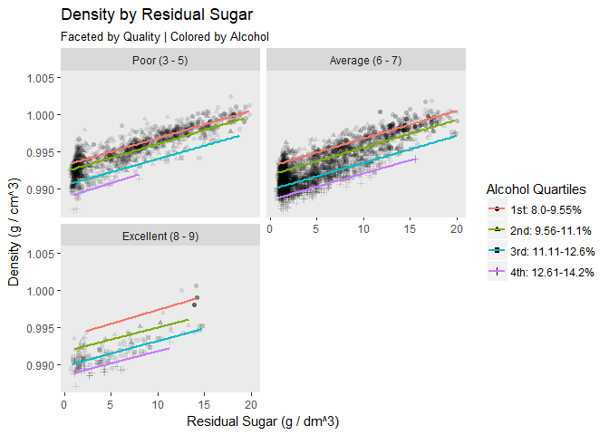

### Description Three

Combining the most useful insights together into one plot, viewing density by residual.sugar, faceted by quality categories, and colored by alcohol quartiles affords a clearer picture of separation between the features comprising different qualities of white wine. Provided data points for alcohol, density, and residual.sugar, one could reasonably build a linear regression model to predict quality ratings using a formula similar to the following:

```r
lm(quality ~ alcohol + residual.sugar + density, data = white)
```

```
##
## Call:
## lm(formula = quality ~ alcohol + residual.sugar + density, data = white)
##
## Coefficients:
##    (Intercept)         alcohol  residual.sugar         density
##       90.31292         0.24587         0.05332       -87.88589
```

# Reflection

The most significant reflection is I need more practice using R for data visualization. While producing quick and dirty plots for EDA was not the source of some difficulty, creating publisher-ready plots with titles, legends, labelled axes, etc., bogged me down and extended the time I expected this project to take.

Another point is I wish there were higher levels of correlation between features. There were not very clearly delineated relationships. I suppose that is more common that one would expect, but it was a little frustrating at times trying to demonstrate relationships that would be described as moderate at best.

On a personl level, I’m interested to know which wine types corresponded to which flavor profiles. I have my personal preferences for taste and I’m very curious to see where those wines line up in terms of their quality. It has no analytical significance for the project; it simply piqued my curiosity in exploring my tastes in wine.